# Module 3

Brooke Wolford

2025-12-08

### License

This work is licensed under a Creative Commons Attribution 4.0 International License (CC BY 4.0). To view a copy of this license, visit: https://creativecommons.org/licenses/by/4.0/

### Sources

Content for this Module is derived from * https://rebeccabarter.com/blog/2020-03-25_machine_learning * https://education.rstudio.com/blog/2020/02/conf20-intro-ml/ * https://www.r-bloggers.com/2020/05/using-xgboost-with-tidymodels/#google_vignette * https://rpubs.com/leoohyama/tidymodelstitanic

ChatGPT was used in the creation of examples and explanations.

### Objectives

By the end of the session, participants will be able to: * Understand key concepts in AI & machine learning. * Perform data preprocessing for ML tasks. * Train and evaluate basic models using caret, tidymodels, randomForest, and xgboost. * Interpret key model evaluation metrics.

### Introduction

AI versus Machine Learning

Machine learning is a subset of AI. “Artificial intelligence refers to the general ability of computers to emulate human thought and perform tasks in real-world environments, while machine learning refers to the technologies and algorithms that enable systems to identify patterns, make decisions, and improve themselves through experience and data.” Deep learning is a type of machine learning using neural networks. You can read more:

- https://ai.engineering.columbia.edu/ai-vs-machine-learning/
- https://professionalprograms.mit.edu/blog/technology/machine-learning-vs-artificial-intelligence/
- https://www.ibm.com/think/topics/ai-vs-machine-learning-vs-deep-learning-vs-neural-networks

### Machine learning in R

The original package for machine learning in R is `caret`: Caret stands for Classification And Regression Training. More recently, `tidymodels` was to developed to use the grammar of the tidyverse as a collection of modelling packages. `caret` is more widely used while `tidymodels` offers a modern, modular approach.

Just as tidyverse has libraries within it such as dplyr and tidyr, tidymodels has libraries within it too. The key ones are:

rsample:sample splitting (e.g. train/test or cross-validation)

recipes:pre-processing

parsnip: specifying the model

yardstick: evaluating the model

```r
library(tidymodels)
library(dplyr)
library(readr)
library(tidyr)
library(randomForest)
library(ranger)
library(xgboost)
library(janitor)
library(skimr)
library(workflows)
library(tune)
library(mlbench)
```

### Exploratory Data Analysis and Pre-processing

The first step is an exploratory data analysis—-plots and summaries of the data to understand the variables and their distributions. However, we have done that in previous modules.

We will use the Pima Indian Women’s diabetes dataset which contains information on 768 Pima Indian women’s diabetes status, as well as many predictive features. This is built into the `mlbench` library.

```r
#load data from the mlbench package
data("PimaIndiansDiabetes")
df <- PimaIndiansDiabetes

#let's look at the data
glimpse(df)
```

```
## Rows: 768
## Columns: 9
## $ pregnant <dbl> 6, 1, 8, 1, 0, 5, 3, 10, 2, 8, 4, 10, 10, 1, 5, 7, 0, 7, 1, 1…
## $ glucose  <dbl> 148, 85, 183, 89, 137, 116, 78, 115, 197, 125, 110, 168, 139,…
## $ pressure <dbl> 72, 66, 64, 66, 40, 74, 50, 0, 70, 96, 92, 74, 80, 60, 72, 0,…
## $ triceps  <dbl> 35, 29, 0, 23, 35, 0, 32, 0, 45, 0, 0, 0, 0, 23, 19, 0, 47, 0…
## $ insulin  <dbl> 0, 0, 0, 94, 168, 0, 88, 0, 543, 0, 0, 0, 0, 846, 175, 0, 230…
## $ mass     <dbl> 33.6, 26.6, 23.3, 28.1, 43.1, 25.6, 31.0, 35.3, 30.5, 0.0, 37…
## $ pedigree <dbl> 0.627, 0.351, 0.672, 0.167, 2.288, 0.201, 0.248, 0.134, 0.158…
## $ age      <dbl> 50, 31, 32, 21, 33, 30, 26, 29, 53, 54, 30, 34, 57, 59, 51, 3…
## $ diabetes <fct> pos, neg, pos, neg, pos, neg, pos, neg, pos, pos, neg, pos, n…
```

```r
str(df)
```

```
## 'data.frame':    768 obs. of  9 variables:
##  $ pregnant: num  6 1 8 1 0 5 3 10 2 8 ...
##  $ glucose : num  148 85 183 89 137 116 78 115 197 125 ...
##  $ pressure: num  72 66 64 66 40 74 50 0 70 96 ...
##  $ triceps : num  35 29 0 23 35 0 32 0 45 0 ...
##  $ insulin : num  0 0 0 94 168 0 88 0 543 0 ...
##  $ mass    : num  33.6 26.6 23.3 28.1 43.1 25.6 31 35.3 30.5 0 ...
##  $ pedigree: num  0.627 0.351 0.672 0.167 2.288 ...
##  $ age     : num  50 31 32 21 33 30 26 29 53 54 ...
##  $ diabetes: Factor w/ 2 levels "neg","pos": 2 1 2 1 2 1 2 1 2 2 ...
```

```r
summary(df)
```

```
##     pregnant         glucose         pressure         triceps
##  Min.   : 0.000   Min.   :  0.0   Min.   :  0.00   Min.   : 0.00
##  1st Qu.: 1.000   1st Qu.: 99.0   1st Qu.: 62.00   1st Qu.: 0.00
##  Median : 3.000   Median :117.0   Median : 72.00   Median :23.00
##  Mean   : 3.845   Mean   :120.9   Mean   : 69.11   Mean   :20.54
##  3rd Qu.: 6.000   3rd Qu.:140.2   3rd Qu.: 80.00   3rd Qu.:32.00
##  Max.   :17.000   Max.   :199.0   Max.   :122.00   Max.   :99.00
##     insulin           mass          pedigree           age        diabetes
##  Min.   :  0.0   Min.   : 0.00   Min.   :0.0780   Min.   :21.00   neg:500
##  1st Qu.:  0.0   1st Qu.:27.30   1st Qu.:0.2437   1st Qu.:24.00   pos:268
##  Median : 30.5   Median :32.00   Median :0.3725   Median :29.00
##  Mean   : 79.8   Mean   :31.99   Mean   :0.4719   Mean   :33.24
##  3rd Qu.:127.2   3rd Qu.:36.60   3rd Qu.:0.6262   3rd Qu.:41.00
##  Max.   :846.0   Max.   :67.10   Max.   :2.4200   Max.   :81.00
```

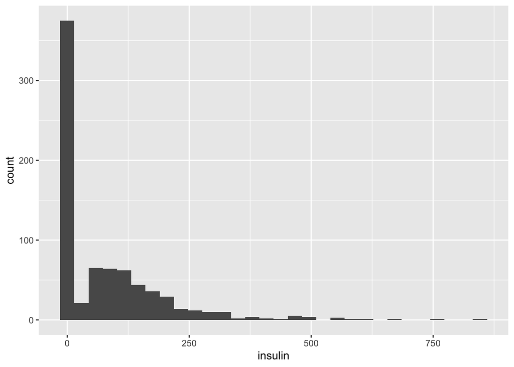

```r
#histogram of insulin values
ggplot(df) +
  geom_histogram(aes(x = insulin))
```

```r
#what do you think about the overabundance of values of 0?
#it turns out that the NA values are coded as 0 in this dataset

#lets convert 0 to NA for the relevant columns
df_clean <- df %>%
  mutate_at(vars(triceps, glucose, pressure, insulin, mass),
            function(.var) {
              if_else(condition = (.var == 0), # if true (i.e. the entry is 0)
                      true = as.numeric(NA),  # replace the value with NA
                      false = .var # otherwise leave it as it is
                      )
            })
```

### data split

Training data is used for the model training and hyperparameter tuning. Once trained, the model can be evaluated against test data to assess accuracy.

This split can be done automatically using the inital_split() function (from rsample) which creates a special “split” object.

It is important to set a random seed beore using a function that uses randomness (e.g. shuffling data, sampling, or simulations). This allows you to get the exact same sequence of random numbers each time and makes your code testable.

```r
set.seed(1234) #set a seed so we have a reproducible split

# split the data into training (75%) and testing (25%)
df_split <- initial_split(df_clean, prop = 3/4)
df_split
```

```
## <Training/Testing/Total>
## <576/192/768>
```

```r
# extract training and testing sets
df_train <- training(df_split)
df_test <- testing(df_split)

# create cross validation object from training data
df_cv <- vfold_cv(df_train)

#how many folds does this make by default?
?vfold_cv
```

### Define a recipe

Creating a recipe has two parts which we layer with pipes:

1. Specify the formula (`recipe()`): specify the outcome variable and predictor variables
2. Specify pre-processing steps: define the pre-processing steps, such as imputation of missing data, creating dummy variables, scaling, etc.

Note we use the “role selections” as arguments to the pre-processing steps. They specify that we want to apply the step to “all numeric” variables or “all predictor variables”.

```r
# define the recipe
my_recipe <-
  # which consists of the formula (outcome ~ predictors)
  recipe(diabetes ~ pregnant + glucose + pressure + triceps +
           insulin + mass + pedigree + age,
         data = df_clean) %>%
  # and some pre-processing steps
  step_normalize(all_numeric()) %>%
  step_impute_knn(all_predictors())

?recipes::selections

#look at how many predictor variables we’ve specified and the steps we’ve specified
summary(my_recipe)
```

```
## # A tibble: 9 × 4
##   variable type      role      source
##   <chr>    <list>    <chr>     <chr>
## 1 pregnant <chr [2]> predictor original
## 2 glucose  <chr [2]> predictor original
## 3 pressure <chr [2]> predictor original
## 4 triceps  <chr [2]> predictor original
## 5 insulin  <chr [2]> predictor original
## 6 mass     <chr [2]> predictor original
## 7 pedigree <chr [2]> predictor original
## 8 age      <chr [2]> predictor original
## 9 diabetes <chr [3]> outcome   original
```

```r
my_recipe
```

```
## ── Recipe ──────────────────────────────────────────────────────────────────────
```

```
## ── Inputs
```

```
## Number of variables by role
```

```
## outcome:   1
## predictor: 8
```

```
## ── Operations
```

```
## • Centering and scaling for: all_numeric()
```

```
## • K-nearest neighbor imputation for: all_predictors()
```

```r
# preprocessing
df_train_preprocessed <- my_recipe %>%
  # apply the recipe to the training data
  prep(df_train) %>%
  # extract the pre-processed training dataset
  juice()
df_train_preprocessed
```

```
## # A tibble: 576 × 9
##    pregnant glucose pressure triceps insulin   mass pedigree     age diabetes
##       <dbl>   <dbl>    <dbl>   <dbl>   <dbl>  <dbl>    <dbl>   <dbl> <fct>
##  1   1.00    1.27     1.09    0.244   0.545  -0.273   -0.958  1.15   pos
##  2  -0.818   1.33    -0.0285  0.866   1.18    0.971    2.50  -0.0190 pos
##  3   0.698   1.99     1.73    0.0747  0.482   1.23     3.28   0.985  neg
##  4  -0.212  -0.643   -0.0285  0.0558 -0.0745 -0.678    0.888 -0.521  neg
##  5  -0.212   2.32    -0.189   0.150   0.626   0.378   -0.710 -0.689  pos
##  6  -0.818  -1.70    -1.95   -1.07   -0.702  -1.72    -0.442 -0.940  neg
##  7  -1.12    0.0811   1.89   -0.924   0.0362 -1.42    -0.641 -1.02   neg
##  8   0.0916 -0.347    0.452   0.998  -0.393   1.03    -0.726  0.399  neg
##  9   0.698  -0.873    0.132  -0.585  -0.854  -1.24    -0.876 -0.438  neg
## 10  -0.818   1.13    -0.0285 -0.792   0.0577 -0.967   -1.10  -0.772  neg
## # ℹ 566 more rows
```

Note that we used the original df_clean data object rather than the df_train object or the df_split object. We could have used any of these. At this point recipes only takes the names and roles of the outcome and predictor variable from the data object. We will apply this recipe to specific datasets later.

### Specify model with parsnip

`parsnip` offers a unified interface for the massive variety of models that exist in R. This means that you only have to learn one way of specifying a model, and you can use this specification and have it generate a linear model, a random forest model, a support vector machine model, and more with a single line of code.

For model specification you need:

1. The model type: what kind of model you want to fit, set using a different function depending on the model, such as `rand_forest()` for random forest, `logistic_reg()` for logistic regression, `svm_poly()` for a polynomial SVM model etc. The full list of models available via parsnip can be found [here](https://tidymodels.github.io/parsnip/articles/articles/Models.html).
2. The arguments: the model parameter values set using `set_args()`.
3. The engine: the underlying package the model should come from (e.g. “ranger” for the fast C++ implementation of Random Forest or `randomForest` for the original R implementation), set using `set_engine()`.
4. The mode: the type of prediction - since several packages can do both classification (binary/categorical prediction) and regression (continuous prediction), set using `set_mode()`.

A random forest is a machine learning algorithm that uses an ensemble of decision trees to make predictions. It works by training multiple decision trees on different subsets of the data and then combining their outputs to arrive at a final prediction. This ensemble approach generally leads to higher accuracy and better generalization compared to using a single decision tree.

For random forest, we can tune hyperparameters like mtry, the number of randomly selected predictors to consider at each split, or trees, the number of trees in the forest.

```r
#random forest from ranger

rf_model <-
  # specify that the model is a random forest
  rand_forest() %>%
  # specify that the `mtry` parameter needs to be tuned
  set_args(mtry = tune()) %>%
  # select the engine/package that underlies the model
  set_engine("ranger", importance = "impurity") %>%
  # choose either the continuous regression or binary classification mode
  set_mode("classification")

#Note: If you want to be able to examine the variable importance of your final model later, you will need to set importance argument when setting the engine. For ranger, the importance options are "impurity" or "permutation".

# logistic regression from glm model

lr_model <-
  # specify that the model is logistic regression
  logistic_reg() %>%
  # select the engine/package that underlies the model
  set_engine("glm") %>%
  # choose either the continuous regression or binary classification mode
  set_mode("classification")
```

### Workflow

Note, it is only when we tune the parameters or fit the model that the recipe and model frameworks are actually implemented.

```r
# Initiate a workflow, add recipe and model to it
rf_workflow <- workflow() %>%
  add_recipe(my_recipe) %>%
  add_model(rf_model)
```

### Hyperparameter tuning

We will perform tuning on the cross-validation object. We will specify the range of mtry values and then we add a tuning layer to the workflow using `tune_grid()` from the `tune` package. We will consider two metrics from the `yardstick` package—accurary and area under the receiver operator curve.

We will explore the results with `collect_metrics()`.

```r
# specify which values to try
rf_grid <- expand.grid(mtry = c(3, 4, 5))
# extract results
rf_tune_results <- rf_workflow %>%
  tune_grid(resamples = df_cv, #CV object
            grid = rf_grid, # grid of values to try
            metrics = metric_set(accuracy, roc_auc)
            )

# print results
rf_tune_results %>%
  collect_metrics()
```

```
## # A tibble: 6 × 7
##    mtry .metric  .estimator  mean     n std_err .config
##   <dbl> <chr>    <chr>      <dbl> <int>   <dbl> <chr>
## 1     3 accuracy binary     0.781    10  0.0169 Preprocessor1_Model1
## 2     3 roc_auc  binary     0.829    10  0.0155 Preprocessor1_Model1
## 3     4 accuracy binary     0.762    10  0.0185 Preprocessor1_Model2
## 4     4 roc_auc  binary     0.827    10  0.0151 Preprocessor1_Model2
## 5     5 accuracy binary     0.769    10  0.0178 Preprocessor1_Model3
## 6     5 roc_auc  binary     0.827    10  0.0146 Preprocessor1_Model3
```

Now let’s also tune the trees hyperparameter at the same time as mtry.

```r
#first we edit the model
rf_model <-
  # specify that the model is a random forest
  rand_forest() %>%
  # specify that the `mtry` and `trees` parameter needs to be tuned
  set_args(mtry = tune(),trees=tune()) %>%
  # select the engine/package that underlies the model
  set_engine("ranger", importance = "impurity") %>%
  # choose either the continuous regression or binary classification mode
  set_mode("classification")

#call the workflow again
rf_workflow <- workflow() %>%
  add_recipe(my_recipe) %>%
  add_model(rf_model)

#now we add trees to the grid
rf_grid <- expand.grid(mtry = c(3, 4, 5), trees = c(100, 500,1000))
# extract results
rf_tune_results2 <- rf_workflow %>%
  tune_grid(resamples = df_cv, #CV object
            grid = rf_grid, # grid of values to try
            metrics = metric_set(accuracy, roc_auc)
            )

# print results
rf_tune_results2 %>%
  collect_metrics()
```

```
## # A tibble: 18 × 8
##     mtry trees .metric  .estimator  mean     n std_err .config
##    <dbl> <dbl> <chr>    <chr>      <dbl> <int>   <dbl> <chr>
##  1     3   100 accuracy binary     0.769    10  0.0181 Preprocessor1_Model1
##  2     3   100 roc_auc  binary     0.823    10  0.0149 Preprocessor1_Model1
##  3     4   100 accuracy binary     0.771    10  0.0204 Preprocessor1_Model2
##  4     4   100 roc_auc  binary     0.824    10  0.0167 Preprocessor1_Model2
##  5     5   100 accuracy binary     0.769    10  0.0150 Preprocessor1_Model3
##  6     5   100 roc_auc  binary     0.825    10  0.0142 Preprocessor1_Model3
##  7     3   500 accuracy binary     0.774    10  0.0177 Preprocessor1_Model4
##  8     3   500 roc_auc  binary     0.830    10  0.0153 Preprocessor1_Model4
##  9     4   500 accuracy binary     0.766    10  0.0187 Preprocessor1_Model5
## 10     4   500 roc_auc  binary     0.826    10  0.0155 Preprocessor1_Model5
## 11     5   500 accuracy binary     0.767    10  0.0153 Preprocessor1_Model6
## 12     5   500 roc_auc  binary     0.827    10  0.0152 Preprocessor1_Model6
## 13     3  1000 accuracy binary     0.773    10  0.0196 Preprocessor1_Model7
## 14     3  1000 roc_auc  binary     0.831    10  0.0156 Preprocessor1_Model7
## 15     4  1000 accuracy binary     0.767    10  0.0179 Preprocessor1_Model8
## 16     4  1000 roc_auc  binary     0.830    10  0.0160 Preprocessor1_Model8
## 17     5  1000 accuracy binary     0.774    10  0.0170 Preprocessor1_Model9
## 18     5  1000 roc_auc  binary     0.829    10  0.0154 Preprocessor1_Model9
```

```r
# Let's find the maximum AUROC and accuracy
rf_tune_results2 %>%
  collect_metrics() %>% group_by(.metric) %>% summarize(max(mean))
```

```
## # A tibble: 2 × 2
##   .metric  `max(mean)`
##   <chr>          <dbl>
## 1 accuracy       0.774
## 2 roc_auc        0.831
```

```r
# which parameters do those correspond to?
 rf_tune_results2 %>%
  collect_metrics() %>% group_by(.metric) %>% slice_max(mean, n = 1)
```

```
## # A tibble: 2 × 8
## # Groups:   .metric [2]
##    mtry trees .metric  .estimator  mean     n std_err .config
##   <dbl> <dbl> <chr>    <chr>      <dbl> <int>   <dbl> <chr>
## 1     5  1000 accuracy binary     0.774    10  0.0170 Preprocessor1_Model9
## 2     3  1000 roc_auc  binary     0.831    10  0.0156 Preprocessor1_Model7
```

```r
 # Select best by AUROC
best_auroc <- select_best(rf_tune_results2, metric = "roc_auc")
best_auroc
```

```
## # A tibble: 1 × 3
##    mtry trees .config
##   <dbl> <dbl> <chr>
## 1     3  1000 Preprocessor1_Model7
```

```r
# Select best by accuracy
best_acc <- select_best(rf_tune_results2, metric = "accuracy")
best_acc
```

```
## # A tibble: 1 × 3
##    mtry trees .config
##   <dbl> <dbl> <chr>
## 1     5  1000 Preprocessor1_Model9
```

As you can see, the best AUROC and best accuracy give us different hyperparameters. What to do?

Pick the metric that actually matters for your problem * Accuracy is best if false positives and false negatives cost roughly the same and your classes are balanced. * AUROC is better if you care about ranking cases correctly (e.g., risk scores) or you have class imbalance. It evaluates how well the model separates the classes regardless of a specific threshold. * If you’re in biomedical research, AUROC is often more appropriate than accuracy, because outcomes like disease presence are usually imbalanced, and you care about discrimination rather than just the raw percent correct.

Ideally we would report both metrics but select based on our primary metric of interest. If accuracy and AUROC pull you toward wildly different parameter sets, it may be worth checking why — sometimes it’s due to overfitting to noise in one metric.

```r
# We want to add a layer to our workflow that corresponds to the tuned parameter, i.e. sets mtry to be the value that yielded the best results. If you didn’t tune any parameters, you can skip this step.
param_final <- rf_tune_results2 %>%
  select_best(metric = "roc_auc")
param_final
```

```
## # A tibble: 1 × 3
##    mtry trees .config
##   <dbl> <dbl> <chr>
## 1     3  1000 Preprocessor1_Model7
```

```r
# Finalize workflow with best AUROC params
rf_workflow <- rf_workflow %>%
  finalize_workflow(param_final)
```

### Fit the model

Now we’ve defined the recipe, model, and tuned the model’s parameters. Since all of this information is in the workflow object, we will apply the `last_fit()` function to our workflow and our train/test split object. This will automatically train the model specified by the workflow using the training data, and produce evaluations based on the test set.

Note that the fit object is a data-frame-like object–a tibble with list columns.

You can also extract the test set predictions themselves using the `collect_predictions()` function. Note that there are 192 rows in the predictions object, which corresponds to the number of rows in the test set.

```r
rf_fit <- rf_workflow %>%
  # fit on the training set and evaluate on test set
  last_fit(df_split)

rf_fit
```

```
## # Resampling results
## # Manual resampling
## # A tibble: 1 × 6
##   splits            id               .metrics .notes   .predictions .workflow
##   <list>            <chr>            <list>   <list>   <list>       <list>
## 1 <split [576/192]> train/test split <tibble> <tibble> <tibble>     <workflow>
```

```r
# Extract performance of final model on the test set
test_performance <- rf_fit %>% collect_metrics()
test_performance
```

```
## # A tibble: 3 × 4
##   .metric     .estimator .estimate .config
##   <chr>       <chr>          <dbl> <chr>
## 1 accuracy    binary         0.724 Preprocessor1_Model1
## 2 roc_auc     binary         0.838 Preprocessor1_Model1
## 3 brier_class binary         0.166 Preprocessor1_Model1
```

```r
# Generate predictions from the test set
test_predictions <- rf_fit %>% collect_predictions()
test_predictions
```

```
## # A tibble: 192 × 7
##    .pred_class .pred_neg .pred_pos id                .row diabetes .config
##    <fct>           <dbl>     <dbl> <chr>            <int> <fct>    <chr>
##  1 pos             0.408    0.592  train/test split     5 pos      Preprocessor…
##  2 neg             0.956    0.0439 train/test split     6 neg      Preprocessor…
##  3 neg             0.931    0.0688 train/test split     7 pos      Preprocessor…
##  4 neg             0.680    0.320  train/test split     8 neg      Preprocessor…
##  5 pos             0.253    0.747  train/test split     9 pos      Preprocessor…
##  6 neg             0.688    0.312  train/test split    16 pos      Preprocessor…
##  7 neg             0.633    0.367  train/test split    24 pos      Preprocessor…
##  8 neg             0.642    0.358  train/test split    26 pos      Preprocessor…
##  9 pos             0.267    0.733  train/test split    27 pos      Preprocessor…
## 10 pos             0.279    0.721  train/test split    37 neg      Preprocessor…
## # ℹ 182 more rows
```

```r
nrow(test_predictions)
```

```
## [1] 192
```

```r
nrow(df_test)
```

```
## [1] 192
```

```r
# Generate a confusion matrix
test_predictions %>%
  conf_mat(truth = diabetes, estimate = .pred_class)
```

```
##           Truth
## Prediction neg pos
##        neg  99  35
##        pos  18  40
```

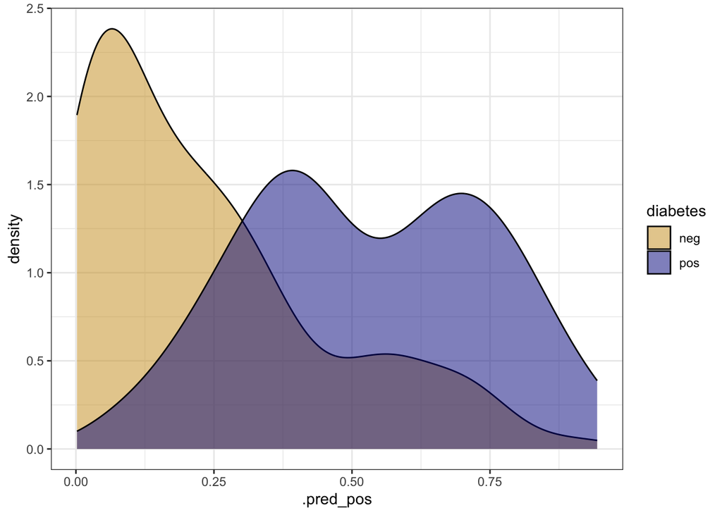

```r
# Plot distributions of the predicted probability distributions for each class

test_predictions %>%
  ggplot() +
  geom_density(aes(x = .pred_pos, fill = diabetes),
               alpha = 0.5) +
  scale_fill_manual(values=c("goldenrod3","darkblue")) +
  theme_bw()
```

### Predicting with our final model

Now that we have our final model, we want to train it on your full dataset and then use it to predict the response for new data.

The object from fit contains a few things including the ranger object trained with the parameters established through the workflow based on the joined test/train data (which is in the original clean data frame).

```r
final_model <- fit(rf_workflow, df_clean)

final_model
```

```
## ══ Workflow [trained] ══════════════════════════════════════════════════════════
## Preprocessor: Recipe
## Model: rand_forest()
##
## ── Preprocessor ────────────────────────────────────────────────────────────────
## 2 Recipe Steps
##
## • step_normalize()
## • step_impute_knn()
##
## ── Model ───────────────────────────────────────────────────────────────────────
## Ranger result
##
## Call:
##  ranger::ranger(x = maybe_data_frame(x), y = y, mtry = min_cols(~3,      x), num.trees = ~1000, importance = ~"impurity", num.threads = 1,      verbose = FALSE, seed = sample.int(10^5, 1), probability = TRUE)
##
## Type:                             Probability estimation
## Number of trees:                  1000
## Sample size:                      768
## Number of independent variables:  8
## Mtry:                             3
## Target node size:                 10
## Variable importance mode:         impurity
## Splitrule:                        gini
## OOB prediction error (Brier s.):  0.1560796
```

```r
# Let's predict risk of disease for a new patient

new_woman <- tribble(~pregnant, ~glucose, ~pressure, ~triceps, ~insulin, ~mass, ~pedigree, ~age,
                     2, 95, 70, 31, 102, 28.2, 0.67, 47)
new_woman
```

```
## # A tibble: 1 × 8
##   pregnant glucose pressure triceps insulin  mass pedigree   age
##      <dbl>   <dbl>    <dbl>   <dbl>   <dbl> <dbl>    <dbl> <dbl>
## 1        2      95       70      31     102  28.2     0.67    47
```

```r
predict(final_model, new_data = new_woman)
```

```
## # A tibble: 1 × 1
##   .pred_class
##   <fct>
## 1 neg
```

### Evaluating Variable Importance

```r
# Extract the underlying ranger model
rf_fit_object <- extract_fit_parsnip(final_model)$fit

# Get variable importance
var_imp <- ranger::importance(rf_fit_object)

# Print sorted importance
sort(var_imp, decreasing = TRUE)
```

```
##  glucose  insulin     mass      age pedigree  triceps pressure pregnant
## 75.79585 51.13954 40.97574 33.64732 29.86078 23.93819 17.57021 16.84465
```

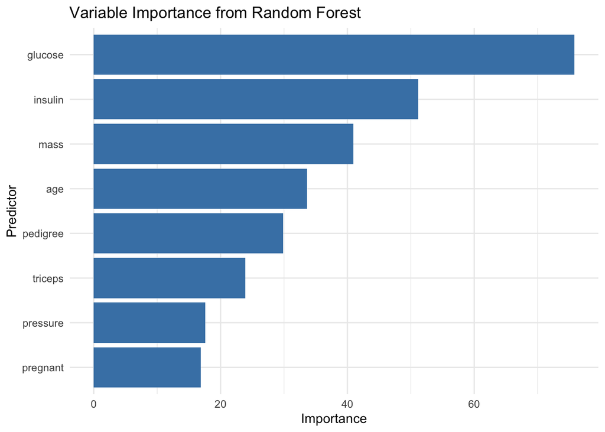

```r
#let's plot the variable importance

#get the results in a data frame for plotting
var_imp_df <- ranger::importance(rf_fit_object) %>%
  as.data.frame() %>%
  rownames_to_column(var = "variable") %>%
  rename(importance = 2) %>%
  arrange(desc(importance))

# point plot
ggplot(var_imp_df, aes(x = reorder(variable, importance), y = importance)) +
  geom_col(fill = "steelblue") +
  coord_flip() +
  labs(
    title = "Variable Importance from Random Forest",
    x = "Predictor",
    y = "Importance"
  ) +
  theme_minimal()
```

### Challenge:

The goal is to use what we have learned with `tidymodels`, `workflow`, and `tune` and run xgboost and glm. Note, XGBoost is robust against highly skewed and/or correlated data, so the amount of preprocessing required is minimal. It is another type of supervised machine learning algorithm.

```r
# Model specification with tuneable parameters
xgb_spec <- boost_tree(
  trees = tune(),
  tree_depth = tune(),
  learn_rate = tune(),
  loss_reduction = tune(),
  sample_size = tune(),
  mtry = tune()
) %>%
  set_mode("classification") %>%
  set_engine("xgboost")

# Preprocessing recipe
xgb_recipe <- recipe(diabetes ~ pregnant + glucose + pressure + triceps +
           insulin + mass + pedigree + age,
         data = df_clean) %>%
  step_dummy(all_nominal_predictors()) %>%   # one-hot encode if needed
  step_zv(all_predictors())                  # remove zero variance cols

# Workflow
xgb_wf <- workflow() %>%
  add_model(xgb_spec) %>%
  add_recipe(xgb_recipe)

# Grid of parameters
xgb_grid <- grid_latin_hypercube(
  trees(range = c(100, 1000)),
  tree_depth(range = c(1, 10)),
  learn_rate(range = c(0.001, 0.3)),
  loss_reduction(range = c(0, 5)),   # gamma
  sample_size = sample_prop(),       # subsample
  mtry(range = c(1, ncol(df_train) - 1)),
  size = 20
)
# Metrics
multi_metrics <- metric_set(accuracy, roc_auc)

# Tune model
xgb_tune <- tune_grid(
  xgb_wf,
  resamples = df_cv,
  grid = xgb_grid,
  metrics = multi_metrics
)

# View results
xgb_tune %>% collect_metrics()
```

```
## # A tibble: 40 × 12
##     mtry trees tree_depth learn_rate loss_reduction sample_size .metric
##    <int> <int>      <int>      <dbl>          <dbl>       <dbl> <chr>
##  1     6   198          1       1.63         358.         0.414 accuracy
##  2     6   198          1       1.63         358.         0.414 roc_auc
##  3     3   737          2       1.27           1.00       0.850 accuracy
##  4     3   737          2       1.27           1.00       0.850 roc_auc
##  5     6   812          2       1.69          20.5        0.759 accuracy
##  6     6   812          2       1.69          20.5        0.759 roc_auc
##  7     2   852          3       1.04         283.         0.556 accuracy
##  8     2   852          3       1.04         283.         0.556 roc_auc
##  9     3   307          3       1.81          58.1        0.541 accuracy
## 10     3   307          3       1.81          58.1        0.541 roc_auc
## # ℹ 30 more rows
## # ℹ 5 more variables: .estimator <chr>, mean <dbl>, n <int>, std_err <dbl>,
## #   .config <chr>
```

```r
# Select best by AUROC
best_auc <- select_best(xgb_tune, metric = "roc_auc")
best_auc
```

```
## # A tibble: 1 × 7
##    mtry trees tree_depth learn_rate loss_reduction sample_size .config
##   <int> <int>      <int>      <dbl>          <dbl>       <dbl> <chr>
## 1     2   369          9       1.17           8.45       0.899 Preprocessor1_Mo…
```

```r
# Finalize workflow with best AUROC params
final_xgb <- finalize_workflow(xgb_wf, best_auc)

# Fit on full training set
final_fit <- fit(final_xgb, data = df_train)

# Evaluate on test set
df_test %>%
  predict(final_fit, ., type = "prob") %>%
  bind_cols(df_test) %>%
  roc_auc(truth = diabetes,.pred_neg)  # AUROC
```

```
## # A tibble: 1 × 3
##   .metric .estimator .estimate
##   <chr>   <chr>          <dbl>
## 1 roc_auc binary         0.775
```

```r
df_test %>%
  predict(final_fit, ., type = "class") %>%
  bind_cols(df_test) %>%
  accuracy(truth = diabetes, estimate = .pred_class)  # Accuracy
```

```
## # A tibble: 1 × 3
##   .metric  .estimator .estimate
##   <chr>    <chr>          <dbl>
## 1 accuracy binary         0.714
```

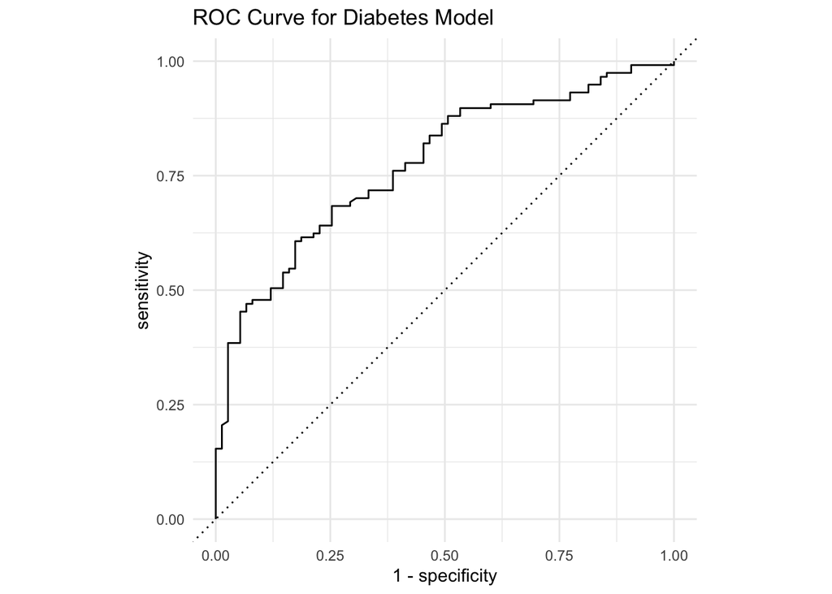

```r
test_results <- predict(final_fit, df_test, type = "prob") %>%
  bind_cols(df_test %>% select(diabetes))  # event level

# Calculate ROC curve data
roc_data <- roc_curve(test_results, truth = diabetes, .pred_neg)

# Plot ROC curve
autoplot(roc_data) +
  ggtitle("ROC Curve for Diabetes Model") +
  theme_minimal()
```